# Aula 03 - RandomForest - Exercício

## Exercício 1

Utilizando o dataset breast_cancer_train.csv, desenvolva um modelo RandomForest (utilizando o sklearn) com o objetivo de prever se o resultado de uma biópsia indica a presença de câncer malígno. Procure fazer com que o seu o modelo não apresente **overfitting** e maximize a acurácia.

Ao final, reporte:

1 - A acurácia, precisão e recall do seu modelo na base utilizada para treino e validação  
2 - A acurácia, precisão e recall do seu modelo na base breast_cancer_test.csv  
3 - Os parâmetros do modelo  
4 - Imagine que o hospital queira diminuir custos no ano seguinte e pretende deixar de colher algumas das variáveis. Quais variáveis você recomendaria a exclusão? Justifique.

```python
import numpy as np
import pandas as pd
import random
import seaborn as sns

from matplotlib import pyplot as plt
from mlxtend.plotting import plot_confusion_matrix
from scipy import stats
from sklearn.ensemble import RandomForestClassifier
from sklearn.metrics import accuracy_score, precision_score, recall_score, confusion_matrix
from sklearn.model_selection import train_test_split
from sklearn.tree import DecisionTreeClassifier, plot_tree
```

```python
df_cancer_train = pd.read_csv('breast_cancer_train.csv')
df_cancer_test = pd.read_csv('breast_cancer_test.csv')
```

```python
# Uma olhada no dataset
df_cancer_train.head()
```

|  | id | diagnosis | radius_mean | texture_mean | perimeter_mean | area_mean | smoothness_mean | compactness_mean | concavity_mean | concave points_mean | ... | radius_worst | texture_worst | perimeter_worst | area_worst | smoothness_worst | compactness_worst | concavity_worst | concave points_worst | symmetry_worst | fractal_dimension_worst |
| --- | --- | --- | --- | --- | --- | --- | --- | --- | --- | --- | --- | --- | --- | --- | --- | --- | --- | --- | --- | --- | --- |
| 0 | 857156 | B | 13.49 | 22.30 | 86.91 | 561.0 | 0.08752 | 0.07698 | 0.047510 | 0.033840 | ... | 15.15 | 31.82 | 99.00 | 698.8 | 0.11620 | 0.17110 | 0.22820 | 0.12820 | 0.2871 | 0.06917 |
| 1 | 844981 | M | 13.00 | 21.82 | 87.50 | 519.8 | 0.12730 | 0.19320 | 0.185900 | 0.093530 | ... | 15.49 | 30.73 | 106.20 | 739.3 | 0.17030 | 0.54010 | 0.53900 | 0.20600 | 0.4378 | 0.10720 |
| 2 | 88330202 | M | 17.46 | 39.28 | 113.40 | 920.6 | 0.09812 | 0.12980 | 0.141700 | 0.088110 | ... | 22.51 | 44.87 | 141.20 | 1408.0 | 0.13650 | 0.37350 | 0.32410 | 0.20660 | 0.2853 | 0.08496 |
| 3 | 88203002 | B | 11.22 | 33.81 | 70.79 | 386.8 | 0.07780 | 0.03574 | 0.004967 | 0.006434 | ... | 12.36 | 41.78 | 78.44 | 470.9 | 0.09994 | 0.06885 | 0.02318 | 0.03002 | 0.2911 | 0.07307 |
| 4 | 892189 | M | 11.76 | 18.14 | 75.00 | 431.1 | 0.09968 | 0.05914 | 0.026850 | 0.035150 | ... | 13.36 | 23.39 | 85.10 | 553.6 | 0.11370 | 0.07974 | 0.06120 | 0.07160 | 0.1978 | 0.06915 |

5 rows × 32 columns

```python
# Distintos valores para a variável-alvo
df_cancer_train['diagnosis'].value_counts()
```

```
B    292
M    163
Name: diagnosis, dtype: int64
```

```python
# Mapeando a variável alvo para valores numéricos
df_cancer_train['diagnosis'] = df_cancer_train['diagnosis'].apply(lambda x : 1 if x == 'M' else 0)
df_cancer_test['diagnosis'] = df_cancer_test['diagnosis'].apply(lambda x : 1 if x == 'M' else 0)
display(df_cancer_train.head(5))
display(df_cancer_test.head(5))
```

|  | id | diagnosis | radius_mean | texture_mean | perimeter_mean | area_mean | smoothness_mean | compactness_mean | concavity_mean | concave points_mean | ... | radius_worst | texture_worst | perimeter_worst | area_worst | smoothness_worst | compactness_worst | concavity_worst | concave points_worst | symmetry_worst | fractal_dimension_worst |
| --- | --- | --- | --- | --- | --- | --- | --- | --- | --- | --- | --- | --- | --- | --- | --- | --- | --- | --- | --- | --- | --- |
| 0 | 857156 | 0 | 13.49 | 22.30 | 86.91 | 561.0 | 0.08752 | 0.07698 | 0.047510 | 0.033840 | ... | 15.15 | 31.82 | 99.00 | 698.8 | 0.11620 | 0.17110 | 0.22820 | 0.12820 | 0.2871 | 0.06917 |
| 1 | 844981 | 1 | 13.00 | 21.82 | 87.50 | 519.8 | 0.12730 | 0.19320 | 0.185900 | 0.093530 | ... | 15.49 | 30.73 | 106.20 | 739.3 | 0.17030 | 0.54010 | 0.53900 | 0.20600 | 0.4378 | 0.10720 |
| 2 | 88330202 | 1 | 17.46 | 39.28 | 113.40 | 920.6 | 0.09812 | 0.12980 | 0.141700 | 0.088110 | ... | 22.51 | 44.87 | 141.20 | 1408.0 | 0.13650 | 0.37350 | 0.32410 | 0.20660 | 0.2853 | 0.08496 |
| 3 | 88203002 | 0 | 11.22 | 33.81 | 70.79 | 386.8 | 0.07780 | 0.03574 | 0.004967 | 0.006434 | ... | 12.36 | 41.78 | 78.44 | 470.9 | 0.09994 | 0.06885 | 0.02318 | 0.03002 | 0.2911 | 0.07307 |
| 4 | 892189 | 1 | 11.76 | 18.14 | 75.00 | 431.1 | 0.09968 | 0.05914 | 0.026850 | 0.035150 | ... | 13.36 | 23.39 | 85.10 | 553.6 | 0.11370 | 0.07974 | 0.06120 | 0.07160 | 0.1978 | 0.06915 |

5 rows × 32 columns

|  | id | diagnosis | radius_mean | texture_mean | perimeter_mean | area_mean | smoothness_mean | compactness_mean | concavity_mean | concave points_mean | ... | radius_worst | texture_worst | perimeter_worst | area_worst | smoothness_worst | compactness_worst | concavity_worst | concave points_worst | symmetry_worst | fractal_dimension_worst |
| --- | --- | --- | --- | --- | --- | --- | --- | --- | --- | --- | --- | --- | --- | --- | --- | --- | --- | --- | --- | --- | --- |
| 0 | 84348301 | 1 | 11.42 | 20.38 | 77.58 | 386.1 | 0.14250 | 0.28390 | 0.24140 | 0.10520 | ... | 14.91 | 26.50 | 98.87 | 567.7 | 0.20980 | 0.86630 | 0.68690 | 0.25750 | 0.6638 | 0.17300 |
| 1 | 84358402 | 1 | 20.29 | 14.34 | 135.10 | 1297.0 | 0.10030 | 0.13280 | 0.19800 | 0.10430 | ... | 22.54 | 16.67 | 152.20 | 1575.0 | 0.13740 | 0.20500 | 0.40000 | 0.16250 | 0.2364 | 0.07678 |
| 2 | 843786 | 1 | 12.45 | 15.70 | 82.57 | 477.1 | 0.12780 | 0.17000 | 0.15780 | 0.08089 | ... | 15.47 | 23.75 | 103.40 | 741.6 | 0.17910 | 0.52490 | 0.53550 | 0.17410 | 0.3985 | 0.12440 |
| 3 | 846226 | 1 | 19.17 | 24.80 | 132.40 | 1123.0 | 0.09740 | 0.24580 | 0.20650 | 0.11180 | ... | 20.96 | 29.94 | 151.70 | 1332.0 | 0.10370 | 0.39030 | 0.36390 | 0.17670 | 0.3176 | 0.10230 |
| 4 | 855133 | 1 | 14.99 | 25.20 | 95.54 | 698.8 | 0.09387 | 0.05131 | 0.02398 | 0.02899 | ... | 14.99 | 25.20 | 95.54 | 698.8 | 0.09387 | 0.05131 | 0.02398 | 0.02899 | 0.1565 | 0.05504 |

5 rows × 32 columns

```python
# Verificando se há dados faltantes
df_cancer_train.info()
```

```
<class 'pandas.core.frame.DataFrame'>
RangeIndex: 455 entries, 0 to 454
Data columns (total 32 columns):
 #   Column                   Non-Null Count  Dtype
---  ------                   --------------  -----
 0   id                       455 non-null    int64
 1   diagnosis                455 non-null    int64
 2   radius_mean              455 non-null    float64
 3   texture_mean             455 non-null    float64
 4   perimeter_mean           455 non-null    float64
 5   area_mean                455 non-null    float64
 6   smoothness_mean          455 non-null    float64
 7   compactness_mean         455 non-null    float64
 8   concavity_mean           455 non-null    float64
 9   concave points_mean      455 non-null    float64
```

[output cut: 24 more lines]

**Sem dados faltantes**

```python
# Verificando se temos registros duplicados...
df_cancer_train.drop_duplicates()['id'].count()
```

```
455
```

**Sem registros duplicados**

```python
# Segregando a variável alvo dos dados
X = df_cancer_train.drop(['diagnosis'], axis=1)
y = df_cancer_train['diagnosis']
```

```python
# Obtendo os datasets de treino e de validação
X_train, X_valid, y_train, y_valid = train_test_split(X,
                                                    y,
                                                    test_size=0.2,
                                                    random_state=10)
```

```python
print(X_train.shape, y_train.shape)
print(X_valid.shape, y_valid.shape)
```

```
(364, 31) (364,)
(91, 31) (91,)
```

```python
modelo = RandomForestClassifier(n_estimators=100, max_depth=3, random_state=10)
modelo
```

```
RandomForestClassifier(max_depth=3, random_state=10)
```

```python
modelo.fit(X_train, y_train)
```

```
RandomForestClassifier(max_depth=3, random_state=10)
```

```python
y_train_pred = modelo.predict(X_train)
y_valid_pred = modelo.predict(X_valid)
print(y_train_pred.shape, y_valid_pred.shape)
```

```
(364,) (91,)
```

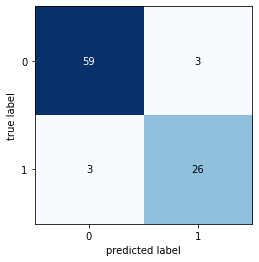

```python
cm = confusion_matrix(y_valid, y_valid_pred)
plot_confusion_matrix(conf_mat=cm)
plt.show()
```

```python
acc_train  = accuracy_score(y_train, y_train_pred)
prec_train = precision_score(y_train, y_train_pred)
rec_train  = recall_score(y_train, y_train_pred)

acc_valid  = accuracy_score(y_valid, y_valid_pred)
prec_valid = precision_score(y_valid, y_valid_pred)
rec_valid  = recall_score(y_valid, y_valid_pred)
```

## Respostas:

1 - A acurácia, precisão e recall do seu modelo na base utilizada para treino e validação

```python
print(f'Treino:\nAcc: {acc_train:.2f}, Precision: {prec_train:.2f}, Recall: {rec_train:.2f}')
print(f'Validação:\nAcc: {acc_valid:.2f}, Precision: {prec_valid:.2f}, Recall: {rec_valid:.2f}')
```

```
Treino:
Acc: 0.98, Precision: 0.99, Recall: 0.96
Validação:
Acc: 0.93, Precision: 0.90, Recall: 0.90
```

2 - A acurácia, precisão e recall do seu modelo na base breast_cancer_test.csv

```python
X_test = df_cancer_test.drop(['diagnosis'], axis=1)
y_test = df_cancer_test['diagnosis']

y_test_pred = modelo.predict(X_test)

acc_test  = accuracy_score(y_test, y_test_pred)
prec_test = precision_score(y_test, y_test_pred)
rec_test  = recall_score(y_test, y_test_pred)

print(f'Teste:\nAcc: {acc_test:.2f}, Precision: {prec_test:.2f}, Recall: {rec_test:.2f}')
```

```
Teste:
Acc: 0.93, Precision: 0.94, Recall: 0.90
```

3 - Os parâmetros do modelo

estimators=100  
max_depth=3  
random_state=10

4 - Imagine que o hospital queira diminuir custos no ano seguinte e pretende deixar de colher algumas das variáveis. Quais variáveis você recomendaria a exclusão? Justifique.

```python
df = pd.DataFrame(np.reshape([X_test.columns.values, modelo.feature_importances_], (2,31)).T)
df = df.sort_values(by=1, ascending=True)
df.head(10)
```

|  | 0 | 1 |
| --- | --- | --- |
| 15 | smoothness_se | 0.000669 |
| 19 | symmetry_se | 0.000854 |
| 10 | fractal_dimension_mean | 0.001091 |
| 0 | id | 0.00133 |
| 16 | compactness_se | 0.001659 |
| 9 | symmetry_mean | 0.001684 |
| 12 | texture_se | 0.002569 |
| 20 | fractal_dimension_se | 0.002817 |
| 2 | texture_mean | 0.003045 |
| 18 | concave points_se | 0.004132 |

**Recomendaria** as variáveis acima, na ordem, pois são as que representam menor importância no modelo de predição.

## Exercício 2

A partir do dataset abaixo, utilize um modelo **RandomForest** para prever, a partir das variáveis de entrada, a probabilidade do individuo receber mais de $50k por ano. Defina um ponto de corte na probabilidade em que, sempre que a probabilidade for maior que o corte, a classe será predita como 1.

Uma descrição do dataset pode ser encontrada [aqui](http://www.cs.toronto.edu/~delve/data/adult/adultDetail.html).

Ao final do exercício, reporte:

1 - O tamanho da base utilizada para treino/validação e o tamanho da base utilizada para teste;  
2 - Um gráfico de barras com a importância de cada variável no precesso de predição;  
3 - A acurácia, precisão e recall de treino, validação e teste;  
4 - Uma comparação com o desempenho de uma árvore de decisão simples.

**Importante**: lembre-se de fazer a divisão do conjunto de teste antes de iniciar o exercício!

```python
import pandas as pd
```

```python
adult_dataset = pd.read_csv('adult.csv')

print(adult_dataset.shape)

adult_dataset.head()
```

```
(48842, 15)
```

|  | age | workclass | fnlwgt | education | educational-num | marital-status | occupation | relationship | race | gender | capital-gain | capital-loss | hours-per-week | native-country | income |
| --- | --- | --- | --- | --- | --- | --- | --- | --- | --- | --- | --- | --- | --- | --- | --- |
| 0 | 25 | Private | 226802 | 11th | 7 | Never-married | Machine-op-inspct | Own-child | Black | Male | 0 | 0 | 40 | United-States | <=50K |
| 1 | 38 | Private | 89814 | HS-grad | 9 | Married-civ-spouse | Farming-fishing | Husband | White | Male | 0 | 0 | 50 | United-States | <=50K |
| 2 | 28 | Local-gov | 336951 | Assoc-acdm | 12 | Married-civ-spouse | Protective-serv | Husband | White | Male | 0 | 0 | 40 | United-States | >50K |
| 3 | 44 | Private | 160323 | Some-college | 10 | Married-civ-spouse | Machine-op-inspct | Husband | Black | Male | 7688 | 0 | 40 | United-States | >50K |
| 4 | 18 | ? | 103497 | Some-college | 10 | Never-married | ? | Own-child | White | Female | 0 | 0 | 30 | United-States | <=50K |

```python
for col in adult_dataset.columns.values:
    print(f'Coluna: {col}:\n')
    display(adult_dataset[col].value_counts())
```

```
Coluna: age:
```

```
36    1348
35    1337
33    1335
23    1329
31    1325
      ...
88       6
85       5
87       3
89       2
86       1
Name: age, Length: 74, dtype: int64
```

```
Coluna: workclass:
```

```
Private             33906
Self-emp-not-inc     3862
Local-gov            3136
?                    2799
State-gov            1981
Self-emp-inc         1695
Federal-gov          1432
Without-pay            21
Never-worked           10
Name: workclass, dtype: int64
```

```
Coluna: fnlwgt:
```

```
203488    21
190290    19
120277    19
125892    18
126569    18
          ..
188488     1
285290     1
293579     1
114874     1
257302     1
Name: fnlwgt, Length: 28523, dtype: int64
```

```
Coluna: education:
```

```
HS-grad         15784
Some-college    10878
Bachelors        8025
Masters          2657
Assoc-voc        2061
11th             1812
Assoc-acdm       1601
10th             1389
7th-8th           955
Prof-school       834
9th               756
12th              657
Doctorate         594
5th-6th           509
1st-4th           247
Preschool          83
Name: education, dtype: int64
```

```
Coluna: educational-num:
```

```
9     15784
10    10878
13     8025
14     2657
11     2061
7      1812
12     1601
6      1389
4       955
15      834
5       756
8       657
16      594
3       509
2       247
1        83
Name: educational-num, dtype: int64
```

```
Coluna: marital-status:
```

```
Married-civ-spouse       22379
Never-married            16117
Divorced                  6633
Separated                 1530
Widowed                   1518
Married-spouse-absent      628
Married-AF-spouse           37
Name: marital-status, dtype: int64
```

```
Coluna: occupation:
```

```
Prof-specialty       6172
Craft-repair         6112
Exec-managerial      6086
Adm-clerical         5611
Sales                5504
Other-service        4923
Machine-op-inspct    3022
?                    2809
Transport-moving     2355
Handlers-cleaners    2072
Farming-fishing      1490
Tech-support         1446
Protective-serv       983
Priv-house-serv       242
Armed-Forces           15
Name: occupation, dtype: int64
```

```
Coluna: relationship:
```

```
Husband           19716
Not-in-family     12583
Own-child          7581
Unmarried          5125
Wife               2331
Other-relative     1506
Name: relationship, dtype: int64
```

```
Coluna: race:
```

```
White                 41762
Black                  4685
Asian-Pac-Islander     1519
Amer-Indian-Eskimo      470
Other                   406
Name: race, dtype: int64
```

```
Coluna: gender:
```

```
Male      32650
Female    16192
Name: gender, dtype: int64
```

```
Coluna: capital-gain:
```

```
0        44807
15024      513
7688       410
7298       364
99999      244
         ...
1111         1
7262         1
22040        1
1639         1
2387         1
Name: capital-gain, Length: 123, dtype: int64
```

```
Coluna: capital-loss:
```

```
0       46560
1902      304
1977      253
1887      233
2415       72
        ...
2465        1
2080        1
155         1
1911        1
2201        1
Name: capital-loss, Length: 99, dtype: int64
```

```
Coluna: hours-per-week:
```

```
40    22803
50     4246
45     2717
60     2177
35     1937
      ...
69        1
87        1
94        1
82        1
79        1
Name: hours-per-week, Length: 96, dtype: int64
```

```
Coluna: native-country:
```

```
United-States                 43832
Mexico                          951
?                               857
Philippines                     295
Germany                         206
Puerto-Rico                     184
Canada                          182
El-Salvador                     155
India                           151
Cuba                            138
England                         127
China                           122
South                           115
Jamaica                         106
Italy                           105
Dominican-Republic              103
Japan                            92
Guatemala                        88
Poland                           87
Vietnam                          86
Columbia                         85
Haiti                            75
Portugal                         67
Taiwan                           65
Iran                             59
Greece                           49
Nicaragua                        49
Peru                             46
Ecuador                          45
France                           38
Ireland                          37
Hong                             30
Thailand                         30
Cambodia                         28
Trinadad&Tobago                  27
Laos                             23
Yugoslavia                       23
Outlying-US(Guam-USVI-etc)       23
Scotland                         21
Honduras                         20
Hungary                          19
Holand-Netherlands                1
Name: native-country, dtype: int64
```

```
Coluna: income:
```

```
<=50K    37155
>50K     11687
Name: income, dtype: int64
```

**Análise das Colunas:**

- age: OK
- workclass: 2799 valores não informados a tratar
- fnlwgt: OK
- education: pode ser desconsiderada para predições, pois temos uma correspondente numérica: educational-num
- educational-num: OK
- marital-status: necessário mapeamento.
- occupation: 2809 valores não informados a tratar. Necessário mapeamento
- relationship: necessário mapeamento
- race: necessário mapeamento
- gender: necessário mapeamento
- capital-gain: OK
- capital-loss: OK
- hours-per-week: OK
- native-country: 857 valores não informados a tratar. Necessário mapeamento
- income: necessário mapeamento.

```python
df_na = adult_dataset.copy()

q_na_workclass  = len(adult_dataset.loc[adult_dataset['workclass'] == '?'])
q_na_occupation = len(adult_dataset.loc[adult_dataset['occupation'] == '?'])
q_na_native_c   = len(adult_dataset.loc[adult_dataset['native-country'] == '?'])

df_na['workclass'] = df_na['workclass'].apply(lambda x : np.nan if x == '?' else x)
df_na['occupation'] = df_na['occupation'].apply(lambda x : np.nan if x == '?' else x)
df_na['native-country'] = df_na['native-country'].apply(lambda x : np.nan if x == '?' else x)
df_na = df_na.dropna()
```

```python
q_tot = len(adult_dataset)
q_na  = q_tot - len(df_na)
print(f'Total de registros: {q_tot}, Registros sem dados: {q_na} = {float(q_na) / q_tot * 100:.2f}%')
print(f'workclass.....: {q_na_workclass:5.0f} = {float(q_na_workclass) / q_tot * 100:4.2f}%')
print(f'occupation....: {q_na_occupation:5.0f} = {float(q_na_occupation) / q_tot * 100:4.2f}%')
print(f'native-country: {q_na_native_c:5.0f} = {float(q_na_native_c) / q_tot * 100:4.2f}%')
```

```
Total de registros: 48842, Registros sem dados: 3620 = 7.41%
workclass.....:  2799 = 5.73%
occupation....:  2809 = 5.75%
native-country:   857 = 1.75%
```

### Decisão:

Vamos definir uma categoria 'X' para workclass e occupation ausentes, e vamos excluir os registros com país nativo ausente (native-country) pois representam menos de 2% da base.

```python
# Liberando memoria
df_na = None
# Uma cópia para preservar o Dataset original
df_ad = adult_dataset.copy()
df_ad['workclass'     ] = df_ad['workclass'     ].apply(lambda x : x if x != '?' else 'X')
df_ad['occupation'    ] = df_ad['occupation'    ].apply(lambda x : x if x != '?' else 'X')
df_ad['native-country'] = df_ad['native-country'].apply(lambda x : x if x != '?' else np.nan)
```

```python
df_ad = df_ad.dropna()
q_tot = len(df_ad)
print(f'Total de registros apos limpeza: {q_tot}')
```

```
Total de registros apos limpeza: 47985
```

```python
# Excluindo a coluna 'education' para a qual já existe uma categorica numérica correspondente
df_ad = df_ad.drop('education', axis=1)
df_ad.head(3)
```

|  | age | workclass | fnlwgt | educational-num | marital-status | occupation | relationship | race | gender | capital-gain | capital-loss | hours-per-week | native-country | income |
| --- | --- | --- | --- | --- | --- | --- | --- | --- | --- | --- | --- | --- | --- | --- |
| 0 | 25 | Private | 226802 | 7 | Never-married | Machine-op-inspct | Own-child | Black | Male | 0 | 0 | 40 | United-States | <=50K |
| 1 | 38 | Private | 89814 | 9 | Married-civ-spouse | Farming-fishing | Husband | White | Male | 0 | 0 | 50 | United-States | <=50K |
| 2 | 28 | Local-gov | 336951 | 12 | Married-civ-spouse | Protective-serv | Husband | White | Male | 0 | 0 | 40 | United-States | >50K |

```python
# Aplicando os mapeamentos

''' Função que gera dict de mapeamento para uma lista fornecida '''
def apply_map(df, col):
    lista = df[col].drop_duplicates().values
    mapper = {}
    for i in range(len(lista)):
        mapper[lista[i]]=i
    df[col] = df[col].map(mapper)

# Aplicando para as colunas em que isso é necessário
for col in ['workclass','marital-status','occupation','relationship','race','gender','native-country','income']:
    apply_map(df_ad, col)
```

```python
# Conferindo
df_ad.head(30)
```

|  | age | workclass | fnlwgt | educational-num | marital-status | occupation | relationship | race | gender | capital-gain | capital-loss | hours-per-week | native-country | income |
| --- | --- | --- | --- | --- | --- | --- | --- | --- | --- | --- | --- | --- | --- | --- |
| 0 | 25 | 0 | 226802 | 7 | 0 | 0 | 0 | 0 | 0 | 0 | 0 | 40 | 0 | 0 |
| 1 | 38 | 0 | 89814 | 9 | 1 | 1 | 1 | 1 | 0 | 0 | 0 | 50 | 0 | 0 |
| 2 | 28 | 1 | 336951 | 12 | 1 | 2 | 1 | 1 | 0 | 0 | 0 | 40 | 0 | 1 |
| 3 | 44 | 0 | 160323 | 10 | 1 | 0 | 1 | 0 | 0 | 7688 | 0 | 40 | 0 | 1 |
| 4 | 18 | 2 | 103497 | 10 | 0 | 3 | 0 | 1 | 1 | 0 | 0 | 30 | 0 | 0 |
| 5 | 34 | 0 | 198693 | 6 | 0 | 4 | 2 | 1 | 0 | 0 | 0 | 30 | 0 | 0 |
| 6 | 29 | 2 | 227026 | 9 | 0 | 3 | 3 | 0 | 0 | 0 | 0 | 40 | 0 | 0 |
| 7 | 63 | 3 | 104626 | 15 | 1 | 5 | 1 | 1 | 0 | 3103 | 0 | 32 | 0 | 1 |
| 8 | 24 | 0 | 369667 | 10 | 0 | 4 | 3 | 1 | 1 | 0 | 0 | 40 | 0 | 0 |
| 9 | 55 | 0 | 104996 | 4 | 1 | 6 | 1 | 1 | 0 | 0 | 0 | 10 | 0 | 0 |
| 10 | 65 | 0 | 184454 | 9 | 1 | 0 | 1 | 1 | 0 | 6418 | 0 | 40 | 0 | 1 |
| 11 | 36 | 4 | 212465 | 13 | 1 | 7 | 1 | 1 | 0 | 0 | 0 | 40 | 0 | 0 |
| 12 | 26 | 0 | 82091 | 9 | 0 | 7 | 2 | 1 | 1 | 0 | 0 | 39 | 0 | 0 |
| 13 | 58 | 2 | 299831 | 9 | 1 | 3 | 1 | 1 | 0 | 0 | 0 | 35 | 0 | 0 |
| 14 | 48 | 0 | 279724 | 9 | 1 | 0 | 1 | 1 | 0 | 3103 | 0 | 48 | 0 | 1 |
| 15 | 43 | 0 | 346189 | 14 | 1 | 8 | 1 | 1 | 0 | 0 | 0 | 50 | 0 | 1 |
| 16 | 20 | 5 | 444554 | 10 | 0 | 4 | 0 | 1 | 0 | 0 | 0 | 25 | 0 | 0 |
| 17 | 43 | 0 | 128354 | 9 | 1 | 7 | 4 | 1 | 1 | 0 | 0 | 30 | 0 | 0 |
| 18 | 37 | 0 | 60548 | 9 | 2 | 0 | 3 | 1 | 1 | 0 | 0 | 20 | 0 | 0 |
| 20 | 34 | 0 | 107914 | 13 | 1 | 9 | 1 | 1 | 0 | 0 | 0 | 47 | 0 | 1 |
| 21 | 34 | 0 | 238588 | 10 | 0 | 4 | 0 | 0 | 1 | 0 | 0 | 35 | 0 | 0 |
| 22 | 72 | 2 | 132015 | 4 | 3 | 3 | 2 | 1 | 1 | 0 | 0 | 6 | 0 | 0 |
| 23 | 25 | 0 | 220931 | 13 | 0 | 5 | 2 | 1 | 0 | 0 | 0 | 43 | 1 | 0 |
| 24 | 25 | 0 | 205947 | 13 | 1 | 5 | 1 | 1 | 0 | 0 | 0 | 40 | 0 | 0 |
| 25 | 45 | 3 | 432824 | 9 | 1 | 6 | 1 | 1 | 0 | 7298 | 0 | 90 | 0 | 1 |
| 26 | 22 | 0 | 236427 | 9 | 0 | 7 | 0 | 1 | 0 | 0 | 0 | 20 | 0 | 0 |
| 27 | 23 | 0 | 134446 | 9 | 4 | 0 | 3 | 0 | 0 | 0 | 0 | 54 | 0 | 0 |
| 28 | 54 | 0 | 99516 | 9 | 1 | 6 | 1 | 1 | 0 | 0 | 0 | 35 | 0 | 0 |
| 29 | 32 | 3 | 109282 | 10 | 0 | 5 | 2 | 1 | 0 | 0 | 0 | 60 | 0 | 0 |
| 30 | 46 | 5 | 106444 | 10 | 1 | 8 | 1 | 0 | 0 | 7688 | 0 | 38 | 0 | 1 |

```python
def simulacoes(df):
    RANDOM_STATE    = 7
    rec_test_prev   = 0
    best_perc_test  = 0
    best_perc_valid = 0
    best_estims     = 0
    best_max_feats  = 0
    best_profund    = 0
    best_min_smp_s  = 0
    best_min_smp_l  = 0
    test = 0

    MIN_SAMPLES_SPLIT = 2
    MIN_SAMPLES_LEAF  = 1
    for ESTIMADORES in [50,100]:
        for MAX_FEATURES in [7,9]:
            for PROFUND_ARVORE in [3,5,7]:
                print(f'#{test}: Estims: {ESTIMADORES}, Max.Feats: {MAX_FEATURES}, '+
                      f'Profund.: {PROFUND_ARVORE}, MSSPT: {MIN_SAMPLES_SPLIT}, MSLF: {MIN_SAMPLES_LEAF}')
                mod_ad = RandomForestClassifier(n_jobs=8,
                                                n_estimators=ESTIMADORES,
                                                max_depth=PROFUND_ARVORE,
                                                max_features=MAX_FEATURES,
                                                random_state=RANDOM_STATE,
                                                min_samples_split=MIN_SAMPLES_SPLIT,
                                                min_samples_leaf=MIN_SAMPLES_LEAF)
                for perc_test in [25,30]:
                    PERC_TEST = float(perc_test) / 100
                    for perc_valid in [10,15]:
                        PERC_VALID = float(perc_valid) / 100
                        test += 1
                        df_ad_test  = df.sample(frac=PERC_TEST, replace=False)
                        df_ad_train = df.drop(df_ad_test.index)

                        X = df_ad_train.drop(['income'], axis=1)
                        y = df_ad_train['income']

                        X_test = df_ad_test.drop(['income'], axis=1)
                        y_test = df_ad_test['income']

                        X_train, X_valid, y_train, y_valid = \
                        train_test_split(X, y, test_size=PERC_VALID, random_state=RANDOM_STATE,)

                        mod_ad.fit(X_train, y_train)

                        y_train_pred = mod_ad.predict(X_train)
                        y_valid_pred = mod_ad.predict(X_valid)

                        acc_train  = accuracy_score(y_train, y_train_pred)
                        prec_train = precision_score(y_train, y_train_pred)
                        rec_train  = recall_score(y_train, y_train_pred)

                        if acc_train < 1 and prec_train < 1:

                            acc_valid  = accuracy_score(y_valid, y_valid_pred)
                            prec_valid = precision_score(y_valid, y_valid_pred)
                            rec_valid  = recall_score(y_valid, y_valid_pred)

                            if acc_valid < 1 and prec_valid < 1:

                                y_test_pred = mod_ad.predict(X_test)

                                acc_test  = accuracy_score(y_test, y_test_pred)
                                prec_test = precision_score(y_test, y_test_pred)
                                rec_test  = recall_score(y_test, y_test_pred)

                                if rec_test > rec_test_prev:
                                    rec_test_prev   = rec_test
                                    best_perc_test  = PERC_TEST
                                    best_perc_valid = PERC_VALID
                                    best_estims     = ESTIMADORES
                                    best_max_feats  = MAX_FEATURES
                                    best_profund    = PROFUND_ARVORE
                                    best_min_smp_s  = MIN_SAMPLES_SPLIT
                                    best_min_smp_l  = MIN_SAMPLES_LEAF
                                    print('>>> #{}: Acc: {:6.2f} Prec: {:6.2f} Rec: {:6.2f} ' \
                                         .format(test,acc_test,prec_test,rec_test))
                                    print(f'RDST: {RANDOM_STATE}', end=' ')
                                    print(f'TTST: {PERC_TEST:.2f}', end=' ')
                                    print(f'TVLD: {PERC_VALID:.2f}', end=' ')
                                    print(f'ESTS: {ESTIMADORES}', end=' ')
                                    print(f'MXFT: {MAX_FEATURES}', end=' ')
                                    print(f'PROF: {PROFUND_ARVORE}', end=' ')
                                    print(f'MSPT: {MIN_SAMPLES_SPLIT}', end=' ')
                                    print(f'MSLF: {MIN_SAMPLES_LEAF}')
    print(f'\n{test} simulacoes executadas.')
    return RANDOM_STATE,best_perc_test,best_perc_valid,best_estims, \
           best_max_feats,best_profund,best_min_smp_s,best_min_smp_l
```